title: “Reproducible Research: Peer Assessment 1”

output:

html_document:

```
keep_md: true
```

## Loading and preprocessing the data

Downloads and unzips the data before storing it in the “data” dataframe

```r
##getting the file from its url

url <- "http://d396qusza40orc.cloudfront.net/repdata%2Fdata%2Factivity.zip"

download.file(url, "repdata-data-activity.zip", mode="wb")

unzip("repdata-data-activity.zip")

data <- read.csv("activity.csv")

##preprocessing the file
```

## What is mean total number of steps taken per day?

Agregates the number of steps taken each date and plots in an histogram

Calculates the mean an median values of steps per day

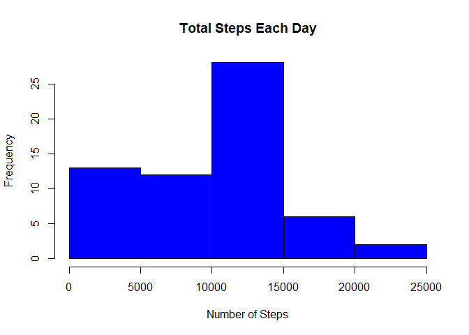

```r
##aggregating the number of steps for each day

stepsbyday <- aggregate(data$steps, by=list(data$date), na.rm=TRUE, FUN=sum)

names(stepsbyday)<-c("day","steps")

##generating the histogram

hist(stepsbyday$steps, main = paste("Total Steps Each Day"), col="blue", xlab="Number of Steps")
```

```r
##calculating the mean and median values

mean_steps <- mean(stepsbyday$steps)

median_steps <- median(stepsbyday$steps)
```

The mean total number of steps by day is 9354.2295082.

The median total number of steps by day is 10395.

## What is the average daily activity pattern?

- Calculate average steps for each interval for all days.
- Plot the Average Number Steps per Day by Interval.
- Find interval with most average steps.

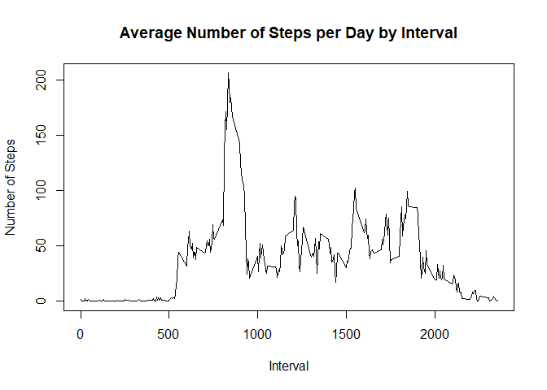

```r
##Agregates the data per interval, using the mean function
stepsbyinterval <- aggregate(data$steps, by=list(data$interval), na.rm=TRUE, FUN=mean)
names(stepsbyinterval)=c("interval","steps")

##Plotting the mean number of steps per interval
plot(stepsbyinterval$interval,stepsbyinterval$steps, type="l", xlab="Interval", ylab="Number of Steps",main="Average Number of Steps per Day by Interval")
```

```r
##Retrieving the interval with the max number of steps
maxinterval <- stepsbyinterval[which.max(stepsbyinterval$steps),1]
```

The interval, which is containing the maximum mean number of steps over all days is 835.

## Imputing missing values

Since we have calculated the mean steps for intervalls from all days, we can replace the missing values by these means and check how this affects the histogram

Here is the new histogram

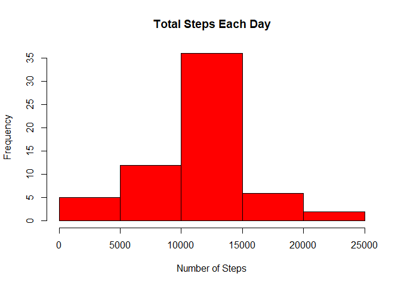

```r
# Writes a vector with FALSE and TRUE (FALSE corespond to a $steps with NA value)

boolean <- complete.cases(data$steps)
#Initializes the completed_data with data
completed_data<-data
##Replaces all NA values
for (i in 1:nrow(data)) {
  if (boolean[i]==FALSE) {
    interval <- data$interval[i]
    step_mean <- stepsbyinterval$steps[
      stepsbyinterval$interval == interval]
    completed_data$steps[i] <- step_mean
  }
}

## calculate  total number of steps taken each day, but this time with imputed valued

##aggregating the number of steps for each day

completed_stepsbyday <- aggregate(completed_data$steps, by=list(completed_data$date), na.rm=TRUE, FUN=sum)

names(completed_stepsbyday)<-c("day","steps")

##generating the histogram

hist(completed_stepsbyday$steps, main = paste("Total Steps Each Day"), col="red", xlab="Number of Steps")
```

```r
##calculating the mean and median values

completed_mean_steps <- mean(completed_stepsbyday$steps)

completed_median_steps <- median(completed_stepsbyday$steps)
```

Plotting both histograms for comparison

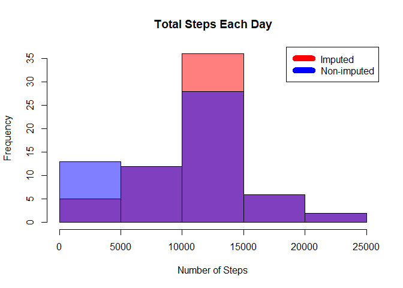

```r
#Create an overlaying histogram to show differences.

hist(completed_stepsbyday$steps, main = paste("Total Steps Each Day"), col=rgb(1,0,0,0.5), xlab="Number of Steps")


hist(stepsbyday$steps, main = paste("Total Steps Each Day"),  col=rgb(0,0,1,0.5), xlab="Number of Steps", add=T)

legend("topright", c("Imputed", "Non-imputed"), col=c("red", "blue"), lwd=10)
```

```r
##calculating the differences in mean and median values

mean_diff <- completed_mean_steps - mean_steps

median_diff <- completed_median_steps - median_steps
```

We can see that we have more days now which are closer to the mean

The difference in the mean total number of steps by day with imputing or without imputing is 1411.959171.

The difference in the median total number of steps by day with imputing or without imputing is 371.1886792.

## Are there differences in activity patterns between weekdays and weekends?

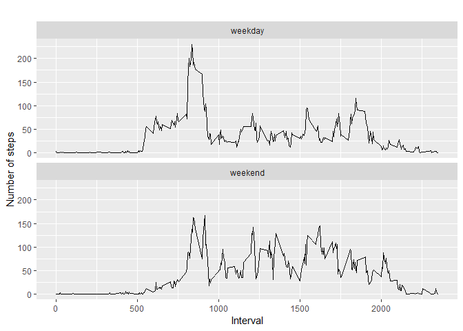

```r
#creating a new column in our dataset, to classify the part of th week (weekend or weekday)
completed_data['weekpart'] <- weekdays(as.Date(completed_data$date))
completed_data$weekpart[completed_data$weekpart  %in% c('samedi','dimanche','Saturday','Sunday') ] <- "weekend"

completed_data$weekpart[completed_data$weekpart != "weekend"] <- "weekday"


# convert $weekpart from character to factor for use as a facet
completed_data$weekpart <- as.factor(completed_data$weekpart)

# calculate average steps by interval across all days
completed_stepsbyinterval <- aggregate(steps ~ interval + weekpart, completed_data, mean)

# plotting the results

library(ggplot2)

qplot(interval,
      steps,
      data = completed_stepsbyinterval,
      type = 'l',
      geom=c("line"),
      xlab = "Interval",
      ylab = "Number of steps",
      main = "") +
  facet_wrap(~ weekpart, ncol = 1)
```

As we can see in the graphic above, the biggest difference is in the morning: the number of steps is increasing earlier on weekdays as for the weekends. As we could expect, our test person stand of a bit later on the week end :-)